# Web APIs

David Moste

3/23/2020

# Introduction

In this assignment, I was asked to connect with the NYT API and import data into an R dataframe. I decided to import data from three different NYT API sections: their live feed, most viewed, and most shared (via facebook).

## Code

After signing up for a NYT API key, the first step was to loas libraries and download each API.

```r
library(jsonlite)
library(tidyverse)
key <- "2rgJQycgUYqUYaZOWbMGtfjtK7ZzUkNh"

live_url <- str_c("https://api.nytimes.com/svc/news/v3/content/all/all.json?api-key=",key)
most_viewed_url <- str_c("https://api.nytimes.com/svc/mostpopular/v2/viewed/1.json?api-key=",key)
most_shared_url <- str_c("https://api.nytimes.com/svc/mostpopular/v2/shared/1/facebook.json?api-key=",key)

live_import <- fromJSON(live_url)
nyt_live_feed <- live_import$results

mv_import <- fromJSON(most_viewed_url)
nyt_most_viewed <- mv_import$results

ms_import <- fromJSON(most_shared_url)
nyt_most_shared <- ms_import$results
```

Next, I compared the three downloads to see if there was any overlap in the articles. It turns out, the only overlap was between the most viewed and most shared articles.

```r
live_and_viewed <- inner_join(nyt_live_feed, nyt_most_viewed, by = "url")
live_and_shared <- inner_join(nyt_live_feed, nyt_most_shared, by = "url")
shared_and_viewed <- inner_join(nyt_most_shared, nyt_most_viewed, by = "url")
```

I was curious about what keywords were in these two libraries, so I performed some data wrangling to get the most used keywords for each of the downloads. I plotted this data just so I could see what keywords were most prevelant in each of the datasets.

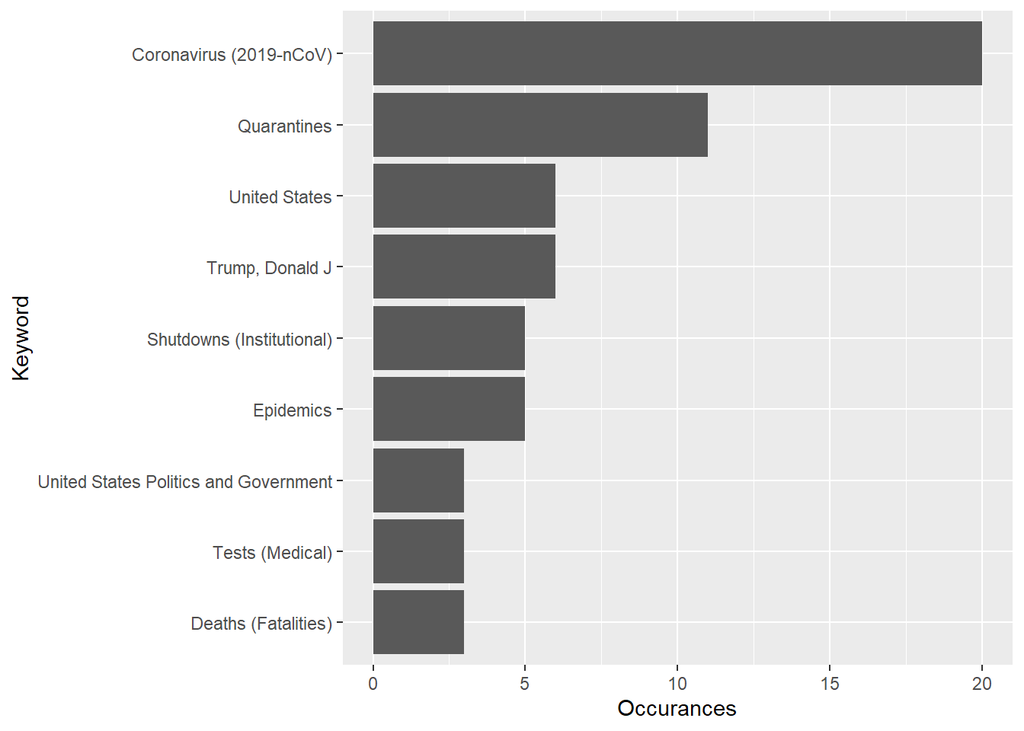

```r
adx_keywords <- str_split(nyt_most_shared$adx_keywords,";")

phrases_shared <- c()
for(i in 1:length(adx_keywords)){
  for(j in 1:length(adx_keywords[[i]])){
    phrases_shared <- rbind(phrases_shared, adx_keywords[[i]][j])
  }
}

keywords_shared <- data.frame(phrases_shared) %>%
  count(phrases_shared) %>%
  filter(n > 2)

names(keywords_shared) <- c("Phrases", "Counts")

ggplot(keywords_shared, aes(x = reorder(Phrases, Counts), y = Counts)) +
  geom_bar(position = "dodge", stat = "identity") +
  labs(x = "Keyword",
       y = "Occurances") +
  coord_flip()
```

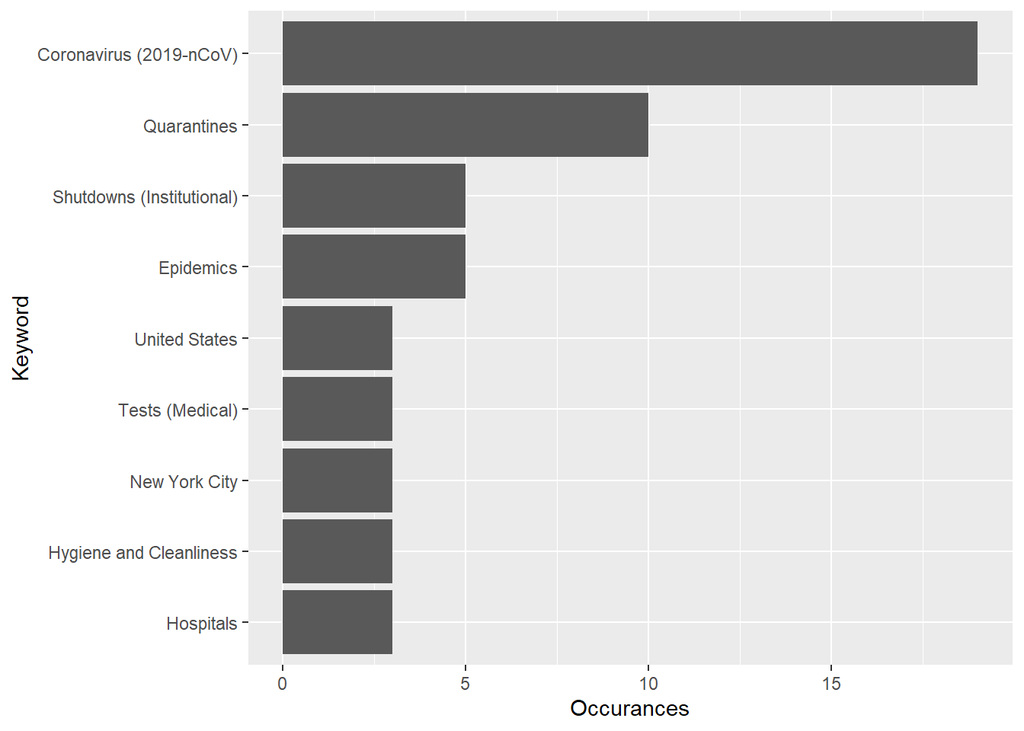

```r
adx_keywords <- str_split(nyt_most_viewed$adx_keywords,";")

phrases_viewed <- c()
for(i in 1:length(adx_keywords)){
  for(j in 1:length(adx_keywords[[i]])){
    phrases_viewed <- rbind(phrases_viewed, adx_keywords[[i]][j])
  }
}

keywords_viewed <- data.frame(phrases_viewed) %>%
  count(phrases_viewed) %>%
  filter(n > 2)

names(keywords_viewed) <- c("Phrases", "Counts")

ggplot(keywords_viewed, aes(x = reorder(Phrases, Counts), y = Counts)) +
  geom_bar(position = "dodge", stat = "identity") +
  labs(x = "Keyword",
       y = "Occurances") +
  coord_flip()
```

Finally, I wanted to combine these datasets and show how these keywords interplayed between the two. This took a little data cleaning, but it was a rather quick process.

```r
all_keywords <- full_join(keywords_shared, keywords_viewed, by = "Phrases")
```

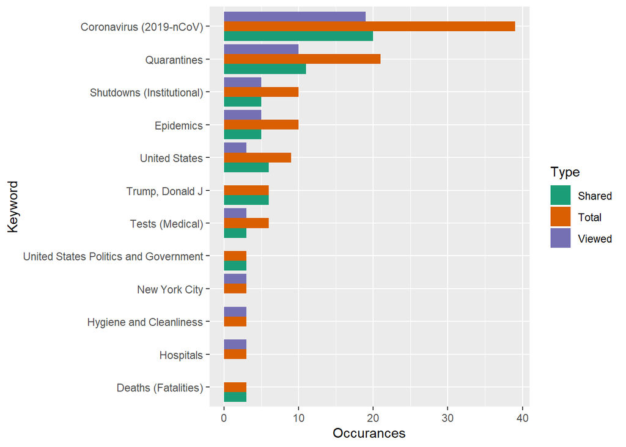

```r
names(all_keywords) <- c("Phrases","Shared","Viewed")
all_keywords$Shared[is.na(all_keywords$Shared)] = 0
all_keywords$Viewed[is.na(all_keywords$Viewed)] = 0
all_keywords$Total <- all_keywords$Shared + all_keywords$Viewed
all_keywords <- pivot_longer(all_keywords,
                             c("Shared","Viewed","Total"),
                             names_to = "Type",
                             values_to = "Count")

ggplot(all_keywords, aes(x = reorder(Phrases, Count), y = Count,
                         fill = Type)) +
  geom_bar(position = "dodge", stat = "identity") +
  scale_fill_brewer(palette = "Dark2") +
  labs(x = "Keyword",
       y = "Occurances",
       fill = "Type") +
  coord_flip()
```

# Conclusion

At this point (03/23/20), coronavirus is clearly the topic of interest (that isn’t a surprise). It consumes every single facet of the 12 most often used keywrods for the most viewed and most shared articles from the NYT. The only surprise (and maybe I’m just naive here) is how incredibly dominating the coronavirus news is. It has something to do with EVERY.SINGLE.ONE of the top 12 keywords in the most viewed and most shared NYT articles. Combining this with the exponential drop-off of keywords after coronavirus, there is a clear topic of interest. This is amazing in my mind.